# Testes de hipóteses para a média

Probest

fnaufel

(v. 17/09/2021)

# 1 Exemplo: duração da gestação

- O tempo de gestação em seres humanos segue a distribuição normal, com média $\mu = 280$ dias e desvio padrão $\sigma = 10$ dias.
- Em uma amostra de $n = 25$ bebês nascidos em uma clínica, o tempo médio de gestação foi de $\bar x = 275$ dias.
- Esta amostra é evidência de que a duração média da gestação humana é *diferente de* $280$ dias?

## 1.1 Hipóteses

- A hipótese de nulidade diz que a duração média da gestação é de $280$ dias:

  $$H_0 : \mu = 280$$
- A hipótese altermativa diz que duração média da gestação é diferente de $280$ dias:

  $$H_A : \mu \neq 280$$

## 1.2 Condições

- Verifique que as condições de independência, aleatoriedade, representatividade e tamanho da amostra são satisfeitas.
- Como a distribuição da população é normal, podemos aceitar $n = 25$.

## 1.3 Valores

- Tamanho da amostra: $n = 25$
- Média amostral: $\bar x = 275$
- Hipótese de nulidade: $H_0 : \mu = 280$
- Hipótese alternativa: $H_A : \mu \neq 280$
- Nível de significância: $\alpha = 0{,}05$

## 1.4 O valor $p$ e a conclusão

- Como a hipótese alternativa envolve “$\neq$”, o teste é bilateral.
- Já sabemos $\sigma$ (o desvio padrão populacional). Não precisamos do desvio padrão amostral.
- A distribuição amostral vai ser a normal com média $\mu = 280$ e desvio padrão

  $$EP = \frac{\sigma}{\sqrt{n}} = \frac{10}{\sqrt{25}} = 2$$
- Usando esta distribuição amostral, calculamos a probabilidade de obter uma amostra como a que obtivemos (com a média amostral $5$ dias menor ou maior que a média suposta por $H_0$) ou mais extrema.
- O valor $p$ vai ser esta probabilidade.

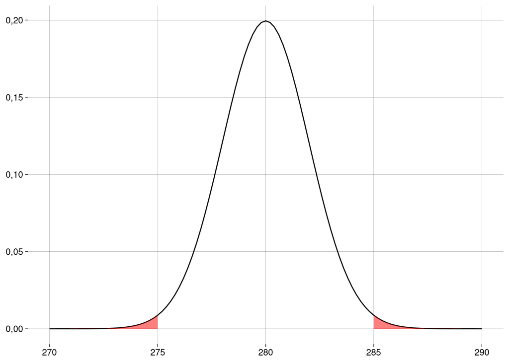

- Calculando em R:

  ```r
  xbar <- 275
  σ <- 10
  n <- 25
  ep <- σ / sqrt(n)
  m0 <- 280
  dif <- abs(m0 - xbar)
  valor_p <- pnorm(xbar, m0, ep) +
    pnorm(m0 + dif, m0, ep, lower.tail = FALSE)
  valor_p
  ```

  ```
  ## [1] 0,01241933
  ```

- Este valor é menor do que $\alpha = 0{,}05$. Logo, nossa amostra é evidência para rejeitar a hipótese de nulidade neste nível de significância.
- Pode parecer surpreendente que $5$ dias façam tanta diferença assim. O problema é que o desvio padrão da população é relativamente baixo: $10$ dias. A variação é pequena. Por isso a diferença entre a média amostral e a média afirmada em $H_0$ é significativa.
- Visto de outro modo: como $\sigma$ é um valor pequeno, o erro padrão (i.e., o desvio padrão da distribuição amostral) também é pequeno; a distribuição amostral, vista na figura acima, é bem estreita, com boa parte da probabilidade bem próxima da média.

## 1.5 Em R

- Vamos carregar um pacote que implementa o teste z:

  ```r
  library(BSDA)
  ```

- Esta função recebe o resumo (*summary*) da amostra:

  ```r
  zsum.test(
    mean.x = xbar,
    sigma.x = σ,
    n.x = n,
    alternative = 'two.sided',
    mu = m0
  )
  ```

  ```
  ##
  ##  One-sample z-Test
  ##
  ## data:  Summarized x
  ## z = -2,5, p-value = 0,01242
  ## alternative hypothesis: true mean is not equal to 280
  ## 95 percent confidence interval:
  ##  271,0801 278,9199
  ## sample estimates:
  ## mean of x
  ##       275
  ```

# 2 Exemplo: salmões novamente

- Numa amostra de $150$ salmões, foi medida a concentração do contaminante [*mirex*](https://en.wikipedia.org/wiki/Mirex), um inseticida banido pela [Convenção de Estocolmo](https://pt.wikipedia.org/wiki/Conven%C3%A7%C3%A3o_de_Estocolmo).
- As concentrações (em ppm) estão resumidas na tabela abaixo.

  | location | mirex |
  | --- | --- |
  | Chile | 0,055 |
  | Chile | 0,057 |
  | Chile | 0,052 |
  | Chile | 0,054 |
  | Chile | 0,057 |
  | Chile | 0,050 |
  | Chile | 0,058 |
  | Chile | 0,060 |
  | Chile | 0,052 |
  | Chile | 0,056 |

  [output cut: 140 more lines]

- A média foi $\overline x = 0{,}09$ppm.
- O desvio padrão *amostral* foi $s = 0{,}05$ppm.
- Não sabemos o desvio padrão *populacional*.
- Alguém nos diz que a concentração máxima de mirex permitida é de $0{,}08$ppm.
- Esta amostra é evidência de que a concentração máxima foi ultrapassada?

## 2.1 Hipóteses

- A hipótese de nulidade diz que a concentração é a máxima permitida ou menor:

  $$H_0 : \mu \leq 0{,}08$$
- A hipótese altermativa diz que a concentração máxima foi ultrapassada:

  $$H_A : \mu > 0{,}08$$

## 2.2 Condições

- Verifique que as condições de independência, aleatoriedade, representatividade e tamanho da amostra são satisfeitas.
- Se precisar, reveja o vídeo sobre intervalos de confiança para a média, onde este exemplo também aparece.

## 2.3 Valores

- Tamanho da amostra: $n = 150$
- Média amostral: $\bar x = 0{,}09$
- Hipótese de nulidade: $H_0 : \mu \leq 0{,}08$
- Hipótese alternativa: $H_A : \mu > 0{,}08$
- Nível de significância: $\alpha = 0{,}05$

## 2.4 O valor $p$ e a conclusão

- Como não sabemos $\sigma$ (o desvio padrão populacional), vamos usar $s$ (o desvio padrão amostral).
- Com isto, a distribuição amostral das médias será a distribuição $t$, com $n - 1 = 149$ graus de liberdade.
- Mas, como a distribuição $t$ tem média $0$, precisamos padronizar a nossa média amostral: subtrair a média que $H_0$ diz ser a verdadeira ($\mu_0 = 0{,}08$) e dividir pelo erro padrão:

  $$t_0 = \frac{\bar x - \mu_0}{EP}$$
- O erro padrão, como vimos nas aulas sobre intervalos de confiança, é

  $$EP = \frac{s}{\sqrt{n}} = \frac{0{,}05}{\sqrt{150}} = 0{,}00$$
- Isto nos dá

  $$t_0 = \frac{\bar x - \mu_0}{EP} = \frac{0{,}09 - 0{,}08}{0{,}00} = 2{,}80$$
- Como a hipótese alternativa envolve “$>$” e não “$\neq$”, o teste é unilateral.
- O valor $p$ é a probabilidade de a média amostral padronizada ser maior do que $t_0$:

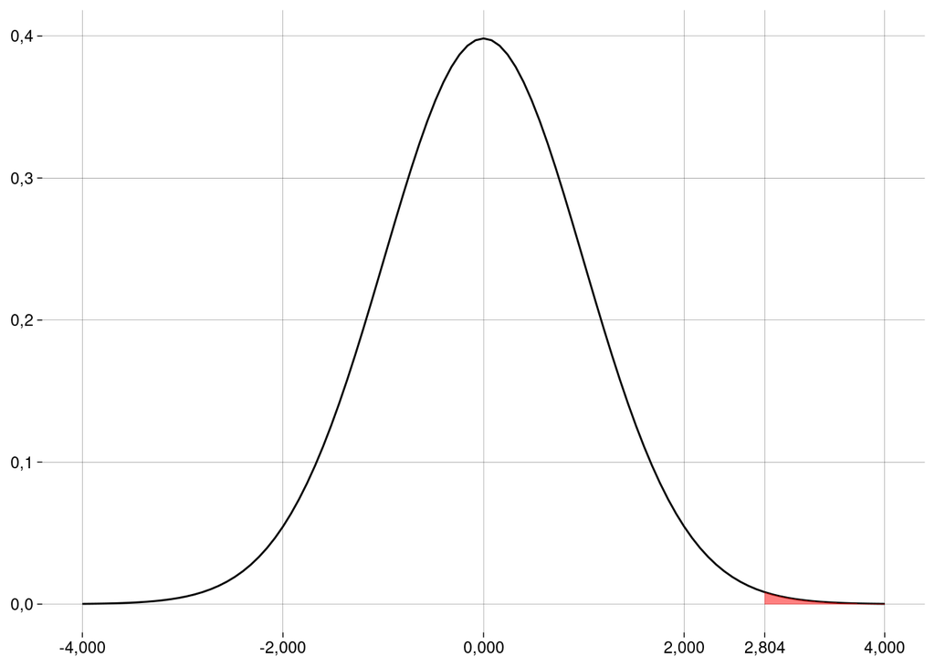

- Este valor pode ser calculado em R (os valores da amostra estão em `salmoes$mirex`):

  ```r
  xbar <- mean(salmoes$mirex)
  s <- sd(salmoes$mirex)
  n <- length(salmoes$mirex)
  ep <- s / sqrt(n)
  m0 <- 0.08
  t0 <- (xbar - m0) / ep
  valor_p <- pt(t0, n - 1, lower.tail = FALSE)
  valor_p
  ```

  ```
  ## [1] 0,002856456
  ```

- Conclusão: como o valor $p$ é menor do que $\alpha$, rejeitamos a hipótese de nulidade. Com este nível de significância, a amostra é evidência de que a contaminação é maior do que a permitida.

## 2.5 Em R

```r
t.test(
  salmoes$mirex,
  alternative = 'greater',
  mu = m0
)
```

```
##
##  One Sample t-test
##
## data:  salmoes$mirex
## t = 2,8044, df = 149, p-value = 0,002856
## alternative hypothesis: true mean is greater than 0,08
## 95 percent confidence interval:
##  0,08464724        Inf
## sample estimates:
## mean of x
##   0,09134
```

# 3 Relação entre testes e IC

- Intervalos de confiança e testes de hipóteses são duas maneiras de enxergar a mesma inferência.
- Lembre-se do exemplo sobre o tempo de gestação:

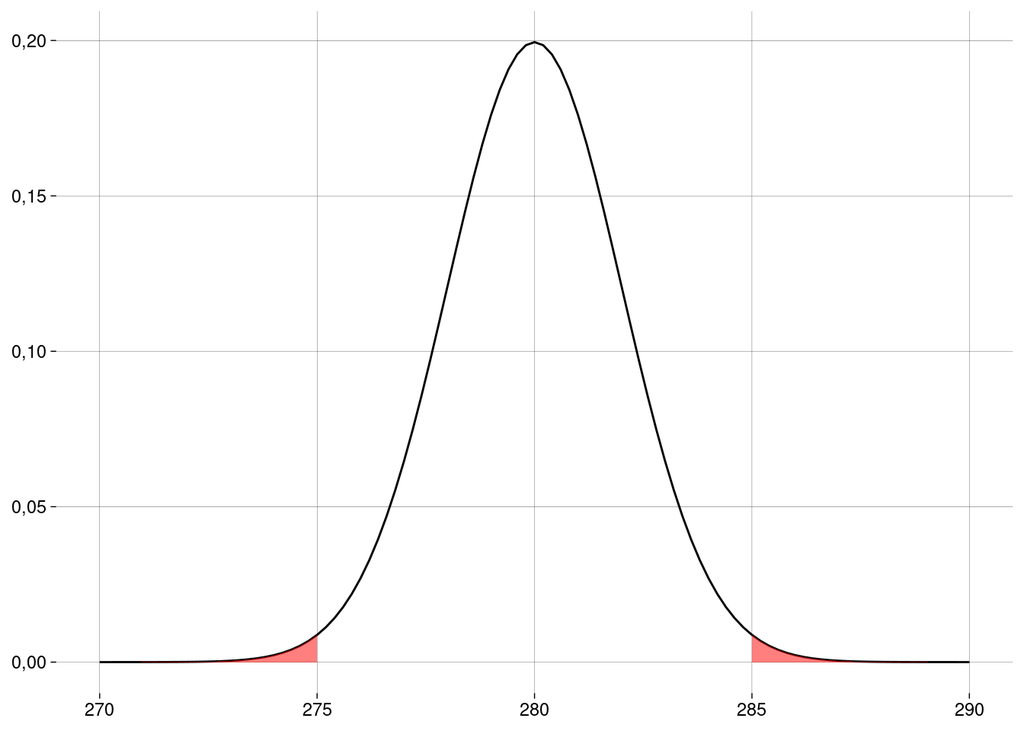

  ```r
  zt <- zsum.test(
    mean.x = xbar,
    sigma.x = σ,
    n.x = n,
    alternative = 'two.sided',
    mu = m0
  )

  zt
  ```

  ```
  ##
  ##  One-sample z-Test
  ##
  ## data:  Summarized x
  ## z = -2,5, p-value = 0,01242
  ## alternative hypothesis: true mean is not equal to 280
  ## 95 percent confidence interval:
  ##  271,0801 278,9199
  ## sample estimates:
  ## mean of x
  ##       275
  ```

- Mantenha fixa a nossa amostra de $25$ gestações.
- A hipótese de nulidade foi rejeitada com $\alpha = 0{,}05$ porque o valor que ela “defendia” ($280$) estava fora do intervalo de confiança de $1 - \alpha = 0{,}95$.
- Reciprocamente, mantendo $\alpha = 0{,}05$, qualquer hipótese de nulidade que não for rejeitada vai “defender” um valor dentro do intervalo de confiança (entre $271{,}08$ e $278{,}92$).
- Experimente rodar a função `zsum.test` com diferentes valores de `mu` para verificar que isto acontece.

# 4 Explorando tudo interativamente (com outro app)

- https://rpsychologist.com/pvalue/

# 5 Exercícios

## 5.1 Gestação

- No exemplo, mude a hipótese alternativa para

  $$H_A : \mu < 280?$$
  - Sem refazer os cálculos, você consegue dizer qual é o novo valor $p$? Compare-o com o valor $p$ original.
  - A hipótese de nulidade continuaria sendo rejeitada?
  - O que mudaria na chamada da função `zsum.test`?

## 5.2 Salmões

- Qual seria o valor $p$ se a média amostral tivesse sido $0{,}08$ppm?
- Qual seria o valor $p$ se as hipóteses fossem

  $$\begin{align*}
  H_0 &: \mu = 0{,}08 \\
  H_A &: \mu \neq 0{,}08
  \end{align*}$$

  e a média amostral tivesse sido $0{,}08$ppm?
- Quando o valor $p$ é $0$?

## 5.3 Testes e IC

- O que acontece com o intervalo de confiança quando o teste de hipótese é unilateral?
- Já que intervalos de confiança e testes de hipóteses contêm a mesma informação, qual dos dois procedimentos você acha mais intuitivo? Mais fácil de executar? Mais fácil de apresentar a um leigo?

## 5.4 App

- Entre em https://rpsychologist.com/pvalue/
- No “painel de controle”, deixe `sample dist. statistic` (estatística da distribuição amostral) em `Mean` (média). Com isto, a curva de baixo vai mostrar a distribuição amostral das médias.
- Qual o efeito, sobre a distribuição amostral, de aumentar o tamanho da amostra? Por quê?
- Defina o tamanho da amostra como $9$.
- O app está configurado para o seguinte teste:

  $$\begin{align*}
  H_0 &: \mu = 100 \\
  H_A &: \mu \neq 100
  \end{align*}$$
- Primeira situação: a hipótese de nulidade é verdadeira.
  1. Faça o que você deve fazer para que, no app, $H_0$ seja verdadeira.  
     Dica: a distribuição populacional “verdadeira” é representada pela curva de cima.
  2. Retire $200$ amostras de $9$ elementos cada, apertando quatro vezes o botão `+50`.
  3. Quantas das $200$ bolinhas são azuis? O que elas significam em termos de médias amostrais? Qual a relação delas com $\alpha$?
  4. Mude `sample dist. statistic` para `Z`.
  5. O que significam os novos rótulos no eixo horizontal da distribuição amostral?
  6. O que significam as linhas pontilhadas verticais? Em que valores do eixo horizontal elas estão?
  7. Se o app nos deixasse mudar essas linhas pontilhadas de posição (o app não deixa), o que isto significaria?
  8. Mude `sample dist. statistic` para `p-value`. Agora, as $200$ amostras aparecem distribuídas de acordo com seus valores $p$.
  9. O que significam as bolinhas azuis?
  10. O que significam as bolinhas vermelhas?
  11. Com $H_0$ verdadeira, como os valores $p$ das $200$ amostras estão distribuídos?
- Segunda situação: a hipótese de nulidade é falsa.
  1. Apague as amostras, clicando em `CLEAR`.
  2. Mude `sample dist. statistic` para `mean`.
  3. Defina o tamanho da amostra como $9$.
  4. Faça o que você deve fazer para que a média populacional passe a ser aproximadamente $110$, tornando $H_0$ falsa.
  5. Retire $200$ amostras de $9$ elementos cada, apertando quatro vezes o botão `+50`.
  6. Qual fração aproximada das $200$ bolinhas são azuis? O que elas significam em termos de médias amostrais? Qual a relação delas com $1 - \beta$ (a potência)?
  7. Você pode alterar o tamanho das amostras agora, e o app vai atualizar as figuras magicamente. Qual deve ser o valor de $n$ para que a potência ultrapasse $0{,}8$?
  8. Mude `sample dist. statistic` para `p-value`.
  9. O que significam as bolinhas azuis?
  10. O que significam as bolinhas vermelhas?
  11. Com $H_0$ falsa, como os valores $p$ das $200$ amostras estão distribuídos?
- Terceira situação: a hipótese de nulidade é falsa, mas não muito.
  1. Apague as amostras, clicando em `CLEAR`.
  2. Faça o que você deve fazer para que a média populacional passe a ser aproximadamente $105$, tornando $H_0$ falsa, mas com uma diferença menor para a média verdadeira.
  3. Refaça os passos restantes da segunda situação.
  4. Comente os resultados.
- Quarta situação: a hipótese de nulidade é falsa, e muito.
  1. Apague as amostras, clicando em `CLEAR`.
  2. Faça o que você deve fazer para que a média populacional passe a ser aproximadamente $120$, tornando $H_0$ falsa, com uma diferença muito grande para a média verdadeira.
  3. Refaça os passos restantes da segunda situação.
  4. Comente os resultados.
- **Desafio:**
  - A curva da parte superior da página, de onde “pingam” as médias amostrais, é uma distribuição normal.
  - Durante os exercícios acima, você descobriu como alterar a média dessa normal.
  - Você consegue calcular o desvio padrão dessa normal?  
    Dica: considere a fórmula que dá o erro padrão da distribuição amostral (a curva de baixo).